# Analysis of the public health and economic effects of storms

Chad Morgan

6/4/2021

# Synopsis

To assess the impact of different types of natural disasters on the economy and public health, I analyzed storm data from NOAA from the years 1950 to 2011.

Prior to the mid-nineties, less event types were covered and they were less consistently recorded. The event types field is not consistent or standardized, containing many similar values and some misspellings. To properly group the events, I used string pattern matching to standardize the classification of event types, focusing on the highest impact events.

Economic impact was measured by the combined property and crop damages, adjusted for inflation using CPI data from FRED. Public health impact was measured by the number of injuries and deaths.

Because of the wide differences in event frequencies, the total impacts per year were computed to compare the impact of each event type. These yearly totals showed that floods are very common and have the greatest economic impact at a median $2.6B in damages per year, tornadoes cause the most injuries with a median 1060 per year, and excessive heat causes the most deaths with a median 83 per year. Hurricanes are relatively rare but cause the third highest damages per year with a median $1.1B per year.

# Data Processing

```r
library(readr)
library(lubridate)
library(stringr)
library(dplyr)
```

```r
library(tibble)
library(tidyr)
library(ggplot2)
library(scales)
theme_set(theme_minimal())
options(scipen=6)
set.seed(789)
```

Refer to the [Storm Data Documentation](https://d396qusza40orc.cloudfront.net/repdata%2Fpeer2_doc%2Fpd01016005curr.pdf) from the NWS for more information

### Reading the data from CSV

The CSV file was downloaded from the Reproducible Research course site.

```r
storm_data_raw <- read_csv("repdata_data_StormData.csv.bz2",
    col_types = cols(BGN_RANGE = col_double(),
        BGN_AZI = col_character(), BGN_LOCATI = col_character(),
        END_DATE = col_character(), END_TIME = col_character(),
        COUNTYENDN = col_character(), END_AZI = col_character(),
        END_LOCATI = col_character(), CROPDMGEXP = col_character(),
        WFO = col_character(), STATEOFFIC = col_character(),
        ZONENAMES = col_character(), REMARKS = col_character()))
```

```r
str(storm_data_raw)
```

```
## tibble [902,297 × 37] (S3: spec_tbl_df/tbl_df/tbl/data.frame)
##  $ STATE__   : num [1:902297] 1 1 1 1 1 1 1 1 1 1 ...
##  $ BGN_DATE  : chr [1:902297] "4/18/1950 0:00:00" "4/18/1950 0:00:00" "2/20/1951 0:00:00" "6/8/1951 0:00:00" ...
##  $ BGN_TIME  : chr [1:902297] "0130" "0145" "1600" "0900" ...
##  $ TIME_ZONE : chr [1:902297] "CST" "CST" "CST" "CST" ...
##  $ COUNTY    : num [1:902297] 97 3 57 89 43 77 9 123 125 57 ...
##  $ COUNTYNAME: chr [1:902297] "MOBILE" "BALDWIN" "FAYETTE" "MADISON" ...
##  $ STATE     : chr [1:902297] "AL" "AL" "AL" "AL" ...
##  $ EVTYPE    : chr [1:902297] "TORNADO" "TORNADO" "TORNADO" "TORNADO" ...
##  $ BGN_RANGE : num [1:902297] 0 0 0 0 0 0 0 0 0 0 ...
##  $ BGN_AZI   : chr [1:902297] NA NA NA NA ...
##  $ BGN_LOCATI: chr [1:902297] NA NA NA NA ...
##  $ END_DATE  : chr [1:902297] NA NA NA NA ...
##  $ END_TIME  : chr [1:902297] NA NA NA NA ...
##  $ COUNTY_END: num [1:902297] 0 0 0 0 0 0 0 0 0 0 ...
##  $ COUNTYENDN: chr [1:902297] NA NA NA NA ...
##  $ END_RANGE : num [1:902297] 0 0 0 0 0 0 0 0 0 0 ...
##  $ END_AZI   : chr [1:902297] NA NA NA NA ...
##  $ END_LOCATI: chr [1:902297] NA NA NA NA ...
##  $ LENGTH    : num [1:902297] 14 2 0.1 0 0 1.5 1.5 0 3.3 2.3 ...
##  $ WIDTH     : num [1:902297] 100 150 123 100 150 177 33 33 100 100 ...
##  $ F         : num [1:902297] 3 2 2 2 2 2 2 1 3 3 ...
##  $ MAG       : num [1:902297] 0 0 0 0 0 0 0 0 0 0 ...
##  $ FATALITIES: num [1:902297] 0 0 0 0 0 0 0 0 1 0 ...
##  $ INJURIES  : num [1:902297] 15 0 2 2 2 6 1 0 14 0 ...
##  $ PROPDMG   : num [1:902297] 25 2.5 25 2.5 2.5 2.5 2.5 2.5 25 25 ...
##  $ PROPDMGEXP: chr [1:902297] "K" "K" "K" "K" ...
##  $ CROPDMG   : num [1:902297] 0 0 0 0 0 0 0 0 0 0 ...
##  $ CROPDMGEXP: chr [1:902297] NA NA NA NA ...
##  $ WFO       : chr [1:902297] NA NA NA NA ...
##  $ STATEOFFIC: chr [1:902297] NA NA NA NA ...
##  $ ZONENAMES : chr [1:902297] NA NA NA NA ...
##  $ LATITUDE  : num [1:902297] 3040 3042 3340 3458 3412 ...
##  $ LONGITUDE : num [1:902297] 8812 8755 8742 8626 8642 ...
##  $ LATITUDE_E: num [1:902297] 3051 0 0 0 0 ...
##  $ LONGITUDE_: num [1:902297] 8806 0 0 0 0 ...
##  $ REMARKS   : chr [1:902297] NA NA NA NA ...
##  $ REFNUM    : num [1:902297] 1 2 3 4 5 6 7 8 9 10 ...
##  - attr(*, "spec")=
##   .. cols(
```

[output cut: 23 more lines]

```
##   ..   INJURIES = col_double(),
##   ..   PROPDMG = col_double(),
##   ..   PROPDMGEXP = col_character(),
##   ..   CROPDMG = col_double(),
##   ..   CROPDMGEXP = col_character(),
##   ..   WFO = col_character(),
##   ..   STATEOFFIC = col_character(),
##   ..   ZONENAMES = col_character(),
##   ..   LATITUDE = col_double(),
##   ..   LONGITUDE = col_double(),
##   ..   LATITUDE_E = col_double(),
##   ..   LONGITUDE_ = col_double(),
##   ..   REMARKS = col_character(),
##   ..   REFNUM = col_double()
##   .. )
```

## Processing date time fields

Convert the character date fields to date format and extract the year and month.

According to the data documentation, additional lines should be in the data if the event spans over several months

```r
storm_data_raw$begin_date <- mdy_hms(storm_data_raw$BGN_DATE)
storm_data_raw$end_date <- mdy_hms(storm_data_raw$END_DATE)

storm_data_raw$event_year <-year(storm_data_raw$begin_date)
storm_data_raw$event_month <-month(storm_data_raw$begin_date)
```

```r
storm_data_raw %>%
    head() %>%
    select(BGN_DATE,begin_date,event_year,event_month)
```

```
## # A tibble: 6 x 4
##   BGN_DATE           begin_date          event_year event_month
##   <chr>              <dttm>                   <dbl>       <dbl>
## 1 4/18/1950 0:00:00  1950-04-18 00:00:00       1950           4
## 2 4/18/1950 0:00:00  1950-04-18 00:00:00       1950           4
## 3 2/20/1951 0:00:00  1951-02-20 00:00:00       1951           2
## 4 6/8/1951 0:00:00   1951-06-08 00:00:00       1951           6
## 5 11/15/1951 0:00:00 1951-11-15 00:00:00       1951          11
## 6 11/15/1951 0:00:00 1951-11-15 00:00:00       1951          11
```

## Processing damage dollar value fields

#### Examine damage fields

From the data documentation:

> Estimates should be rounded to three significant digits, followed by an alphabetical character signifying the magnitude of the number, i.e., 1.55B for $1,550,000,000. Alphabetical characters used to signify magnitude include “K” for thousands, “M” for millions, and “B” for billions

So PROPDMGEXP should contain a character K, M, B, etc. to indicate the magnitude of the dollar amount in PROPDMG

```r
storm_data_raw %>%
    filter(PROPDMG>0) %>%
    group_by(PROPDMGEXP) %>%
    summarize(n=n()) %>%
    arrange(desc(n))
```

```
## # A tibble: 16 x 2
##    PROPDMGEXP      n
##    <chr>       <int>
##  1 K          227481
##  2 M           11319
##  3 0             209
##  4 <NA>           76
##  5 B              40
##  6 5              18
##  7 m               7
##  8 H               6
##  9 +               5
## 10 4               4
## 11 6               3
## 12 7               2
## 13 -               1
## 14 2               1
## 15 3               1
## 16 h               1
```

```r
storm_data_raw %>%
    filter(CROPDMG>0) %>%
    group_by(CROPDMGEXP) %>%
    summarize(n=n()) %>%
    arrange(desc(n))
```

```
## # A tibble: 7 x 2
##   CROPDMGEXP     n
##   <chr>      <int>
## 1 K          20137
## 2 M           1918
## 3 k             21
## 4 0             12
## 5 B              7
## 6 <NA>           3
## 7 m              1
```

We are seeing some digits and the characters + and -, which were not expected. Let’s take a look at some of these rows

```r
storm_data_raw %>%
    filter(PROPDMGEXP == '0' & PROPDMG>0) %>%
    select(BGN_DATE,PROPDMG,REMARKS) %>%
    head
```

```
## # A tibble: 6 x 3
##   BGN_DATE        PROPDMG REMARKS
##   <chr>             <dbl> <chr>
## 1 12/3/1994 0:00…   150   Highest tides of the year combined with 35 mph south …
## 2 8/10/1994 0:00…    50   <NA>
## 3 8/10/1994 0:00…     5   Lightning struck a house in Westminster causing a sma…
## 4 8/11/1994 0:00…    37   Lightning struck an Arvada house causing destruction …
## 5 8/12/1994 0:00…     0.5 A tornado touched down causing tree to smash into the…
## 6 8/13/1994 0:00…     0.5 <NA>
```

Unfortunately I can’t clearly tell what these other values for PROPDMGEXP could mean, so I will treat those property damage values as missing values.

#### Damage field cleanup and processing

Below we will make a quick function to calculate the damage value from the DMG and EXP values

```r
get_damage_value <- function(DMG,DMG_EXP){

    exp_lookup <- data.frame(tribble(
        ~exp_value, ~damage_multiplier,
        'h',100,
        'H',100,
        'k',1000,
        'K',1000,
        'm',1e6,
        'M',1e6,
        'B',1e9
    ))

    mult_v <- exp_lookup[match(DMG_EXP,exp_lookup$exp_value),'damage_multiplier']
    result <- ifelse(DMG == 0,DMG,DMG*mult_v)

    return(result)
}
```

```r
# a few quick tests of the fucnction
get_damage_value(c(2,12,1,0,1),c('h','m','B','+','+'))
```

```
## [1]        200   12000000 1000000000          0         NA
```

Use our function to calculate the damages to property and crops

```r
storm_data_raw <- storm_data_raw %>%
    mutate(
        property_damage_value = get_damage_value(as.numeric(PROPDMG),PROPDMGEXP),
        crop_damage_value = get_damage_value(as.numeric(CROPDMG),CROPDMGEXP),
        total_damages = property_damage_value + crop_damage_value
    )
```

Check some rows to verify the calculation worked

```r
storm_data_raw %>%
    select(PROPDMG,PROPDMGEXP,property_damage_value) %>%
    filter(PROPDMG>0) %>%
    sample_n(10)
```

```
## # A tibble: 10 x 3
##    PROPDMG PROPDMGEXP property_damage_value
##      <dbl> <chr>                      <dbl>
##  1    25   K                          25000
##  2     5   K                           5000
##  3     5   K                           5000
##  4    20   K                          20000
##  5     0.5 K                            500
##  6    25   K                          25000
##  7     5   K                           5000
##  8     5   K                           5000
##  9    50   K                          50000
## 10     3   K                           3000
```

## Adjust dollar values for inflation

Since we have data spanning decades, we should adjust the dollars for the effects of inflation

### download CPI data

We can download monthly CPI values from FRED at https://fred.stlouisfed.org/data/CPIAUCNS.txt

Below is the header of this data:

```
Title:               Consumer Price Index for All Urban Consumers: All Items in U.S. City Average
Series ID:           CPIAUCNS
Source:              U.S. Bureau of Labor Statistics
Release:             Consumer Price Index
Seasonal Adjustment: Not Seasonally Adjusted
Frequency:           Monthly
Units:               Index 1982-1984=100
Date Range:          1913-01-01 to 2021-04-01
Last Updated:        2021-05-12 7:38 AM CDT
Notes:               Handbook of Methods (https://www.bls.gov/opub/hom/pdf/cpihom.pdf)
                     Understanding the CPI: Frequently Asked Questions
                     (https://www.bls.gov/cpi/questions-and-answers.htm)
```

```r
cpi_monthly <- read_table('https://fred.stlouisfed.org/data/CPIAUCNS.txt',skip=13)
```

Reindex the CPI values relative to Nov 2011, the last month available in the storm dataset

```r
cpi_monthly <- cpi_monthly %>%
    mutate(
        year = year(DATE),
        month = month(DATE)
    )

cpi_nov2011 <- cpi_monthly %>%
    filter(year == 2011 & month == 11) %>%
    select(VALUE) %>%
    as.numeric

cpi2011_table <- cpi_monthly %>%
    mutate(
        cpi_base2011 = (VALUE / cpi_nov2011)
    ) %>%
    select(year,month,cpi_base2011) %>%
    rename(
        event_year = year,
        event_month = month
    )
```

Adjust the damage dollars using the CPI

```r
storm_data_raw <- storm_data_raw %>%
    left_join(cpi2011_table,by = c('event_year','event_month')) %>%
    mutate(
        damages_adjusted = total_damages / cpi_base2011
    )
```

## Fatalities and injuries processing

Check the fatalities and injuries fields to make sure they look OK to use

```r
storm_data_raw %>%
    select(FATALITIES,INJURIES) %>%
    summary
```

```
##    FATALITIES          INJURIES
##  Min.   :  0.0000   Min.   :   0.0000
##  1st Qu.:  0.0000   1st Qu.:   0.0000
##  Median :  0.0000   Median :   0.0000
##  Mean   :  0.0168   Mean   :   0.1557
##  3rd Qu.:  0.0000   3rd Qu.:   0.0000
##  Max.   :583.0000   Max.   :1700.0000
```

These values look good and don’t seem to need imputation or any other pre-processing

## Standardize and reduce the event types to the most important

There are many event types with inconsistent values that should be standardized before proceeding

```r
storm_data_raw %>%
    group_by(EVTYPE) %>%
    summarize(
        obs=n(),
        log10_damages = log10(sum(damages_adjusted,na.rm=TRUE)+1),
        total_deaths = sum(FATALITIES)
    ) %>%
    arrange(desc(obs)) %>%
    head(10)
```

```
## # A tibble: 10 x 4
##    EVTYPE                obs log10_damages total_deaths
##    <chr>               <int>         <dbl>        <dbl>
##  1 HAIL               288661         10.4            15
##  2 TSTM WIND          219944          9.82          504
##  3 THUNDERSTORM WIND   82563          9.62          133
##  4 TORNADO             60652         11.2          5633
##  5 FLASH FLOOD         54278         10.3           978
##  6 FLOOD               25326         11.2           470
##  7 THUNDERSTORM WINDS  20843          9.47           64
##  8 HIGH WIND           20212          9.84          248
##  9 LIGHTNING           15755          9.07          816
## 10 HEAVY SNOW          15708          9.17          127
```

Make a function to help us standardize the event classification using pattern matching

```r
simplify_event_types <- function(raw_event_types){

    pattern_helper <- function(input_string,output_string,replace_value,pattern_list){


        detection_output <- lapply(input_string, function(u) pattern_list[str_detect(u, pattern_list)])
        nr_matches <- unlist(lapply(detection_output,length))

        return(ifelse(nr_matches>0,replace_value,output_string))
    }

    evnt_in <- str_to_lower(raw_event_types)
    evnt_out <- rep('',length(raw_event_types))

    evnt_out <- pattern_helper(evnt_in,evnt_out,'wind',c('wind','wnd','gust'))
    evnt_out <- pattern_helper(evnt_in,evnt_out,'rain',c('rain','precipitation','precipatation'))
    evnt_out <- pattern_helper(evnt_in,evnt_out,'lightning',c('lightning','ligntning','lighting'))
    evnt_out <- pattern_helper(evnt_in,evnt_out,'hail',c('hail'))
    evnt_out <- pattern_helper(evnt_in,evnt_out,'thunderstorm',c('thunderstorm','tstm'))


    evnt_out <- pattern_helper(evnt_in,evnt_out,'cold',c('cold','wind chill','windchill','freeze','frost','low temp','cool','record low'))
    evnt_out <- pattern_helper(evnt_in,evnt_out,'winter weather / blizzard',c('winter','wintry','ice','blizzard','snow','freezing rain','sleet'))

    evnt_out <- pattern_helper(evnt_in,evnt_out,'flood ',c('flood','fld','rising water','floood'))
    evnt_out <- pattern_helper(evnt_in,evnt_out,'storm surge/tsunami ',c('storm surge','tsunami'))

    evnt_out <- pattern_helper(evnt_in,evnt_out,'rip current/high surf',c('rip current','surf','seas'))
    evnt_out <- pattern_helper(evnt_in,evnt_out,'avalanche/slide',c('avalanche','avalance','mudslide','slide','landslump'))

    evnt_out <- pattern_helper(evnt_in,evnt_out,'tornado',c('tornado','torndao'))
    evnt_out <- pattern_helper(evnt_in,evnt_out,'hurricane',c('hurricane','typhoon'))
    evnt_out <- pattern_helper(evnt_in,evnt_out,'tropical storm/depression',c('tropical storm','tropical depression'))

    evnt_out <- pattern_helper(evnt_in,evnt_out,'wildfire',c('wildfire','forest fire','wild fire','brush fire','grass fire'))
    evnt_out <- pattern_helper(evnt_in,evnt_out,'heat',c('heat','warm','high temp','hot','record high'))
    evnt_out <- pattern_helper(evnt_in,evnt_out,'drought',c('drought'))

    evnt_out <- ifelse(evnt_out=='','other',evnt_out)

    return(evnt_out)

}
```

Apply our function to the EVTYPE values

```r
event_type_map <- data.frame('EVTYPE' = unique(storm_data_raw$EVTYPE))
event_type_map$event_type <- simplify_event_types(event_type_map$EVTYPE)
```

Join the mappings back to the dataset

```r
storm_data_raw <- storm_data_raw %>%
    left_join(event_type_map,by = 'EVTYPE')
```

```r
storm_data_raw %>%
    group_by(event_type) %>%
    summarize( obs=n(),
        log10_damages = log10(sum(damages_adjusted,na.rm=TRUE)+1),
        total_deaths = sum(FATALITIES)
    ) %>%
    arrange(desc(total_deaths))
```

```
## # A tibble: 18 x 4
##    event_type                     obs log10_damages total_deaths
##    <chr>                        <int>         <dbl>        <dbl>
##  1 "tornado"                    60701         11.2          5661
##  2 "heat"                        2990          9.07         3172
##  3 "flood "                     86122         11.3          1554
##  4 "lightning"                  15768          9.08          817
##  5 "rip current/high surf"       1978          8.28          763
##  6 "thunderstorm"              336801         10.2           729
##  7 "winter weather / blizzard"  42592         10.4           655
##  8 "cold"                        4211          9.69          460
##  9 "wind"                       26325          9.92          441
## 10 "avalanche/slide"             1042          8.60          269
## 11 "other"                      14313          8.48          154
## 12 "hurricane"                    299         11.0           135
## 13 "rain"                       11939          9.75          101
## 14 "wildfire"                    4237         10.0            90
## 15 "tropical storm/depression"    757         10.0            66
## 16 "storm surge/tsunami "         429         10.7            57
## 17 "hail"                      289281         10.4            15
## 18 "drought"                     2512         10.3             6
```

## Narrow the dataset

Keep only the columns we need for analysis and exclude event types of “other”

```r
storm_data_filtered <- storm_data_raw %>%
    filter(event_type != 'other') %>%
    select(
        REFNUM, event_year, event_month, event_type, damages_adjusted, FATALITIES, INJURIES
    ) %>%
    rename(
        refnum = REFNUM,
        deaths = FATALITIES,
        injuries = INJURIES
    ) %>% mutate(
        log10_damages = log10(damages_adjusted+1)
    )
```

# Results

### Average effects per event by type

```r
effects_per_event <- storm_data_filtered %>%
    group_by(event_type) %>%
    summarize(
        nr_events = n(),
        avg_damages = mean(damages_adjusted,na.rm=TRUE),
        median_damages = median(damages_adjusted,na.rm=TRUE),
        avg_deaths = mean(deaths),
        avg_injuries = mean(injuries)
    ) %>%
    arrange(desc(avg_deaths)) %>% data.frame
effects_per_event
```

```
##                   event_type nr_events  avg_damages median_damages   avg_deaths
## 1                       heat      2990    396110.05          0.000 1.0608695652
## 2                  hurricane       299 364158091.36    1873242.038 0.4515050167
## 3      rip current/high surf      1978     96326.29          0.000 0.3857431749
## 4            avalanche/slide      1042    383452.46          0.000 0.2581573896
## 5       storm surge/tsunami        429 128005517.79       9970.955 0.1328671329
## 6                       cold      4211   1154061.42          0.000 0.1092377108
## 7                    tornado     60701   2401601.46      14501.923 0.0932604076
## 8  tropical storm/depression       757  13933106.50      10945.589 0.0871862616
## 9                  lightning     15768     75734.08       6291.157 0.0518138001
## 10                  wildfire      4237   2602157.43          0.000 0.0212414444
## 11                    flood      86122   2475844.98          0.000 0.0180441699
## 12                      wind     26325    314734.08          0.000 0.0167521368
## 13 winter weather / blizzard     42592    600656.43          0.000 0.0153784748
## 14                      rain     11939    473494.25          0.000 0.0084596700
```

[output cut: 21 more lines]

Some events have many more observations and may be more common throughout the year

```r
effects_per_event$event_type_factor <-  factor(effects_per_event$event_type,levels = as.character(effects_per_event[order(effects_per_event$nr_events),'event_type']))
```

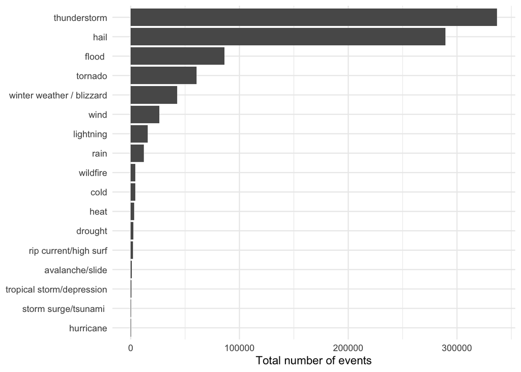

```r
ggplot(effects_per_event,aes(event_type_factor,nr_events))+
    geom_bar(stat='identity')+
    coord_flip()+
    ylab("Total number of events")+xlab(NULL)
```

In this plot we can see that thunderstorms and hail are extremely common, followed by floods, tornadoes, and winter storms. Tsunamis and Hurricanes and very rare by comparison.

### Yearly total effects by event type

Hurricanes are very rare but we will see later that they appear to have a large impact per event, whereas more frequent events such as floods may have a smaller average impact but the total impact over time may add up. Because of this large disparity in frequencies, we will next add up the total effects of each event type over each year.

```r
yearly_storm_events <- storm_data_filtered %>%
    group_by(event_year,event_type) %>%
    summarize(
        nr_events = n(),
        total_damages = sum(damages_adjusted,na.rm=TRUE),
        damages_millions = total_damages/1e6,
        total_deaths = sum(deaths),
        total_injuries = sum(injuries)
    )
```

#### Frequency of event types recorded by year

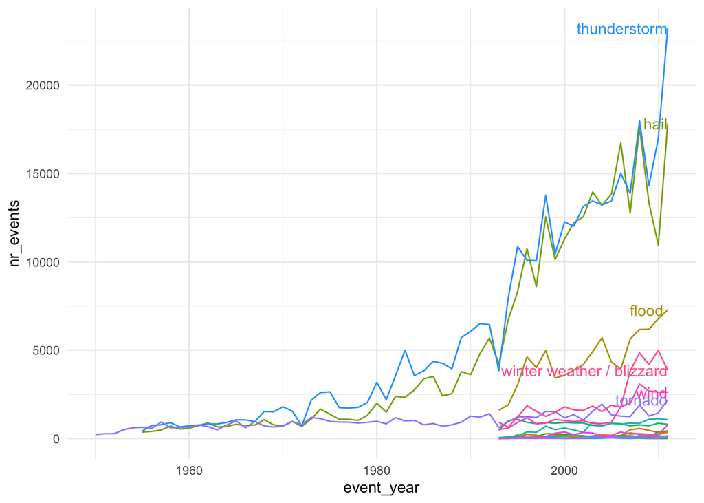

```r
ggplot(yearly_storm_events,aes(event_year,nr_events,color=event_type))+
    geom_line()+
    geom_text(data=subset(yearly_storm_events,event_year==2011 & nr_events > 2000),aes(event_year,nr_events,color=event_type,label=event_type),hjust = "inward")+
    theme(legend.position="none")
```

From this time series plot we can see that before the mid nineties, only thunderstorms, hail, and tornadoes were recorded, so we should be cautious about not comparing total counts across the entire time range of the dataset, but instead should look at averages per year. We can also see that the number of many of these type of events are increasing over time.

### Average yearly effects per event type

```r
avg_impact_per_year <- yearly_storm_events %>%
    group_by(event_type) %>%
    summarize(
        nr_events = sum(nr_events),
        avg_yearly_damages = mean(total_damages),
        median_yearly_damages = median(total_damages),
        avg_yearly_deaths = mean(total_deaths),
        median_yearly_deaths = median(total_deaths),
        avg_yearly_injuries = mean(total_injuries),
        median_yearly_injuries = median(total_injuries)
    ) %>% data.frame
```

### Plot the effect per event by type

Let’s next plot the distribution of each outcome per event type using boxplots

```r
top5deaths_per_year <- avg_impact_per_year %>% arrange(desc(avg_yearly_deaths)) %>% head(5) %>% select(event_type)
top5injuries_per_year <- avg_impact_per_year %>% arrange(desc(avg_yearly_injuries)) %>% head(5) %>% select(event_type)
top5damages_per_year <- avg_impact_per_year %>% arrange(desc(avg_yearly_damages)) %>% head(5) %>% select(event_type)

top_impact_per_year <- unique(unlist(c(top5deaths_per_year,top5injuries_per_year,top5damages_per_year)))

top_effects_per_year <- data.frame(yearly_storm_events %>% filter(event_type %in% top_impact_per_year))
```

```r
yearly_storm_events_long <- yearly_storm_events %>%
    filter(event_type %in% top_impact_per_year) %>%
    pivot_longer(
        names_to = 'outcome',
        cols = c(damages_millions,total_deaths,total_injuries)
    )
```

```r
yearly_storm_events_long$event_type_factor <- factor(yearly_storm_events_long$event_type,levels = as.character(avg_impact_per_year[order(avg_impact_per_year$median_yearly_damages),'event_type']))

yearly_storm_events_long$damanges_millions <- yearly_storm_events_long$total_damages/1e6
```

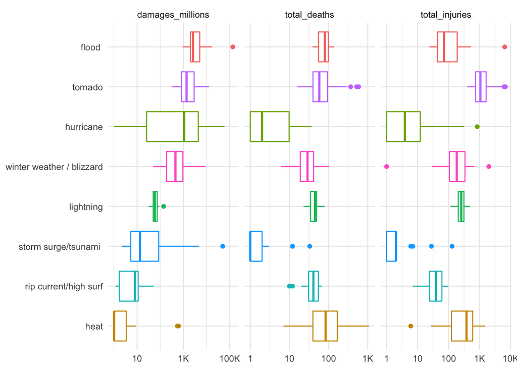

```r
# note: add 1 to the value so values of zero can be log transformed
ggplot(yearly_storm_events_long,aes(value+1,event_type_factor,color=event_type))+
    geom_boxplot()+
    facet_wrap(~outcome,nrow = 1,scales = 'free_x') +
    theme(legend.position='none')+
    scale_x_log10(label=label_number_si()) +
    ylab(NULL)+xlab(NULL)
```

From these boxplots we can see that floods, tornadoes and hurricanes cause a lot of damage; floods, tornadoes and heat cause a lot of deaths and injuries. We can also see that hurricanes, storm surges, and excessive heat have high variability in their yearly impact, whereas floods and lightning have a more consistent impact across years.

## Top event types per outcome

We will use the median yearly impact because there are extreme outliers for each outcome

### Median yearly damages

Floods create the highest median damages per year, followed by tornadoes and hurricanes.

```r
avg_impact_per_year %>%
    select(event_type,nr_events,avg_yearly_damages,median_yearly_damages) %>%
    arrange(desc(median_yearly_damages)) %>%
    head(3)
```

```
##   event_type nr_events avg_yearly_damages median_yearly_damages
## 1     flood      86122        11216359587            2594295827
## 2    tornado     60701         2350703004            1367080154
## 3  hurricane       299         6049070518            1090709996
```

### Median yearly deaths

Excessive heat leads to the most deaths per year, followed by floods and tornadoes.

```r
avg_impact_per_year %>%
    select(event_type,nr_events,avg_yearly_deaths,median_yearly_deaths) %>%
    arrange(desc(median_yearly_deaths)) %>%
    head(3)
```

```
##   event_type nr_events avg_yearly_deaths median_yearly_deaths
## 1       heat      2990         166.94737                   83
## 2     flood      86122          81.78947                   79
## 3    tornado     60701          91.30645                   57
```

### Median yearly injuries

Tornadoes lead to the most injuries per year, followed by heat and lightning.

```r
avg_impact_per_year %>%
    select(event_type,nr_events,avg_yearly_injuries,median_yearly_injuries) %>%
    arrange(desc(median_yearly_injuries)) %>%
    head(3)
```

```
##   event_type nr_events avg_yearly_injuries median_yearly_injuries
## 1    tornado     60701           1474.3065                   1060
## 2       heat      2990            485.6842                    378
## 3  lightning     15768            275.3158                    256
```

# Summary of findings

- Floods have a high economic and public health impact, being the third most frequent event per year and causing the highest median damages at $2.6B per year and cause the second highest median deaths at 79 per year
- Tornadoes also have a high impact, being the fourth more common event and causing the highest median injuries at 1060 per year, second highest median damages at $1.4B, and third highest median yearly deaths at 57 per year
- Excessive heat is the most deadly event at median 83 per year, but has a relatively small economic impact compared to floods, tornadoes, and hurricanes
- Hurricanes are relatively infrequent, but they tend to have a large economic impact, causing the third highest median damages at $1.1B per year